# Introduction to Computer Vision: Plant Seedlings Classification

## Model Building

Let's create a CNN model sequentially, where we will be adding the layers one after another.

First, we need to clear the previous model's history from the session even if a single model can run multiple times on the same data.

In Keras, we need a special command to clear the model's history, otherwise the previous model history remains in the backend.

Also, let's fix the seed again after clearing the backend.

Let's **set the seed for random number generators in Numpy, the Random library in Python, and in TensorFlow** to be able to reproduce the same results every time we run the code.

```python
# Clearing backend
from tensorflow.keras import backend
backend.clear_session()
```

```python
# Fixing the seed for random number generators
import random
np.random.seed(42)
random.seed(42)
tf.random.set_seed(42)
```

Now, let's build a **CNN Model** with the following 2 main parts -

1. **The Feature Extraction layers** which are comprised of convolutional and pooling layers.
2. **The Fully Connected classification layers** for prediction.

```python
# Intializing a sequential model
model = Sequential()

# Adding first conv layer with 64 filters and kernel size 3x3 , padding 'same' provides the output size same as the input size
# Input_shape denotes input image dimension of images
model.add(Conv2D(64, (3, 3), activation='relu', kernel_regularizer=regularizers.l2(0.001), padding="same", input_shape=(64, 64, 3)))

# Adding max pooling to reduce the size of output of first conv layer
model.add(MaxPooling2D((2, 2), padding = 'same'))
model.add(BatchNormalization())

model.add(Conv2D(32, (3, 3), activation='relu',kernel_regularizer=regularizers.l2(0.001), padding="same"))
model.add(MaxPooling2D((2, 2), padding = 'same'))
model.add(BatchNormalization())


model.add(Conv2D(32, (3, 3), activation='relu', kernel_regularizer=regularizers.l2(0.001), padding="same"))
model.add(MaxPooling2D((2, 2), padding = 'same'))
model.add(BatchNormalization())


model.add(Conv2D(16, (3, 3), activation='relu', kernel_regularizer=regularizers.l2(0.001), padding="same"))
model.add(MaxPooling2D((2, 2), padding = 'same'))


# flattening the output of the conv layer after max pooling to make it ready for creating dense connections
model.add(Flatten())

# Adding a fully connected dense layer with 64 neurons
model.add(Dense(64, activation='relu', kernel_regularizer=regularizers.l2(0.001)))
model.add(Dropout(0.25))
model.add(Dense(32, activation='relu', kernel_regularizer=regularizers.l2(0.001)))
model.add(Dropout(0.25))
model.add(Dense(32, activation='relu', kernel_regularizer=regularizers.l2(0.001)))
# Adding the output layer with 10 neurons and activation functions as softmax since this is a multi-class classification problem
model.add(Dense(12, activation='softmax'))

# Using SGD Optimizer
#opt = SGD(learning_rate=0.001, momentum=0.9)
opt=Adam()
# Compile model
model.compile(optimizer=opt, loss='categorical_crossentropy', metrics=['accuracy'])

# Generating the summary of the model
model.summary()
```

```
Model: "sequential"
```

```
┏━━━━━━━━━━━━━━━━━━━━━━━━━━━━━━━━━━━━━━┳━━━━━━━━━━━━━━━━━━━━━━━━━━━━━┳━━━━━━━━━━━━━━━━━┓
┃ Layer (type)                         ┃ Output Shape                ┃         Param # ┃
┡━━━━━━━━━━━━━━━━━━━━━━━━━━━━━━━━━━━━━━╇━━━━━━━━━━━━━━━━━━━━━━━━━━━━━╇━━━━━━━━━━━━━━━━━┩
│ conv2d (Conv2D)                      │ (None, 64, 64, 64)          │           1,792 │
├──────────────────────────────────────┼─────────────────────────────┼─────────────────┤
│ max_pooling2d (MaxPooling2D)         │ (None, 32, 32, 64)          │               0 │
├──────────────────────────────────────┼─────────────────────────────┼─────────────────┤
│ batch_normalization                  │ (None, 32, 32, 64)          │             256 │
│ (BatchNormalization)                 │                             │                 │
├──────────────────────────────────────┼─────────────────────────────┼─────────────────┤
│ conv2d_1 (Conv2D)                    │ (None, 32, 32, 32)          │          18,464 │
├──────────────────────────────────────┼─────────────────────────────┼─────────────────┤
│ max_pooling2d_1 (MaxPooling2D)       │ (None, 16, 16, 32)          │               0 │
├──────────────────────────────────────┼─────────────────────────────┼─────────────────┤
│ batch_normalization_1                │ (None, 16, 16, 32)          │             128 │
│ (BatchNormalization)                 │                             │                 │
├──────────────────────────────────────┼─────────────────────────────┼─────────────────┤
│ conv2d_2 (Conv2D)                    │ (None, 16, 16, 32)          │           9,248 │
├──────────────────────────────────────┼─────────────────────────────┼─────────────────┤
│ max_pooling2d_2 (MaxPooling2D)       │ (None, 8, 8, 32)            │               0 │
├──────────────────────────────────────┼─────────────────────────────┼─────────────────┤
│ batch_normalization_2                │ (None, 8, 8, 32)            │             128 │
│ (BatchNormalization)                 │                             │                 │
├──────────────────────────────────────┼─────────────────────────────┼─────────────────┤
│ conv2d_3 (Conv2D)                    │ (None, 8, 8, 16)            │           4,624 │
├──────────────────────────────────────┼─────────────────────────────┼─────────────────┤
│ max_pooling2d_3 (MaxPooling2D)       │ (None, 4, 4, 16)            │               0 │
├──────────────────────────────────────┼─────────────────────────────┼─────────────────┤
│ flatten (Flatten)                    │ (None, 256)                 │               0 │
├──────────────────────────────────────┼─────────────────────────────┼─────────────────┤
│ dense (Dense)                        │ (None, 64)                  │          16,448 │
├──────────────────────────────────────┼─────────────────────────────┼─────────────────┤
│ dropout (Dropout)                    │ (None, 64)                  │               0 │
├──────────────────────────────────────┼─────────────────────────────┼─────────────────┤
│ dense_1 (Dense)                      │ (None, 32)                  │           2,080 │
├──────────────────────────────────────┼─────────────────────────────┼─────────────────┤
│ dropout_1 (Dropout)                  │ (None, 32)                  │               0 │
├──────────────────────────────────────┼─────────────────────────────┼─────────────────┤
│ dense_2 (Dense)                      │ (None, 32)                  │           1,056 │
├──────────────────────────────────────┼─────────────────────────────┼─────────────────┤
│ dense_3 (Dense)                      │ (None, 12)                  │             396 │
└──────────────────────────────────────┴─────────────────────────────┴─────────────────┘
```

```
 Total params: 54,620 (213.36 KB)
```

```
 Trainable params: 54,364 (212.36 KB)
```

```
 Non-trainable params: 256 (1.00 KB)
```

### Fitting the model on the train data

```python
history_1 = model.fit(
            X_train_normalized, y_train_encoded,
            epochs=50,
            validation_data=(X_val_normalized,y_val_encoded),
            batch_size=32,
            verbose=2
)
```

```
121/121 - 21s - 177ms/step - accuracy: 0.2137 - loss: 2.5161 - val_accuracy: 0.1379 - val_loss: 2.8958
121/121 - 4s - 36ms/step - accuracy: 0.3855 - loss: 2.0259 - val_accuracy: 0.1379 - val_loss: 4.5367
121/121 - 1s - 10ms/step - accuracy: 0.4838 - loss: 1.7207 - val_accuracy: 0.1379 - val_loss: 4.6124
121/121 - 1s - 7ms/step - accuracy: 0.5459 - loss: 1.5432 - val_accuracy: 0.2593 - val_loss: 2.2558
121/121 - 1s - 10ms/step - accuracy: 0.5875 - loss: 1.4046 - val_accuracy: 0.5607 - val_loss: 1.4387
121/121 - 1s - 7ms/step - accuracy: 0.6293 - loss: 1.3047 - val_accuracy: 0.4883 - val_loss: 1.5513
121/121 - 1s - 7ms/step - accuracy: 0.6522 - loss: 1.2231 - val_accuracy: 0.4930 - val_loss: 1.7187
121/121 - 1s - 11ms/step - accuracy: 0.6857 - loss: 1.1188 - val_accuracy: 0.3715 - val_loss: 2.7904
121/121 - 1s - 7ms/step - accuracy: 0.7115 - loss: 1.0473 - val_accuracy: 0.5911 - val_loss: 1.3823
121/121 - 1s - 10ms/step - accuracy: 0.7346 - loss: 0.9669 - val_accuracy: 0.5958 - val_loss: 1.5644
121/121 - 1s - 7ms/step - accuracy: 0.7601 - loss: 0.9063 - val_accuracy: 0.7477 - val_loss: 1.0565
121/121 - 1s - 8ms/step - accuracy: 0.7816 - loss: 0.8423 - val_accuracy: 0.7150 - val_loss: 1.1441
121/121 - 1s - 11ms/step - accuracy: 0.7967 - loss: 0.8004 - val_accuracy: 0.4346 - val_loss: 2.7210
121/121 - 1s - 10ms/step - accuracy: 0.8035 - loss: 0.7593 - val_accuracy: 0.6402 - val_loss: 1.4961
121/121 - 1s - 7ms/step - accuracy: 0.8048 - loss: 0.7488 - val_accuracy: 0.7617 - val_loss: 0.9806
121/121 - 1s - 7ms/step - accuracy: 0.8269 - loss: 0.6838 - val_accuracy: 0.7617 - val_loss: 0.9714
121/121 - 1s - 7ms/step - accuracy: 0.8378 - loss: 0.6729 - val_accuracy: 0.7360 - val_loss: 1.0806
121/121 - 1s - 10ms/step - accuracy: 0.8495 - loss: 0.6272 - val_accuracy: 0.7850 - val_loss: 0.9667
121/121 - 1s - 10ms/step - accuracy: 0.8490 - loss: 0.6342 - val_accuracy: 0.7570 - val_loss: 1.0273
121/121 - 1s - 10ms/step - accuracy: 0.8638 - loss: 0.5953 - val_accuracy: 0.6449 - val_loss: 1.5561
121/121 - 1s - 7ms/step - accuracy: 0.8529 - loss: 0.6140 - val_accuracy: 0.7126 - val_loss: 1.2809
121/121 - 1s - 7ms/step - accuracy: 0.8747 - loss: 0.5561 - val_accuracy: 0.5164 - val_loss: 2.3539
121/121 - 1s - 7ms/step - accuracy: 0.8708 - loss: 0.5602 - val_accuracy: 0.8107 - val_loss: 0.8952
121/121 - 1s - 7ms/step - accuracy: 0.8750 - loss: 0.5439 - val_accuracy: 0.4790 - val_loss: 3.3017
121/121 - 1s - 8ms/step - accuracy: 0.8781 - loss: 0.5340 - val_accuracy: 0.6846 - val_loss: 1.2111
121/121 - 1s - 8ms/step - accuracy: 0.8848 - loss: 0.5244 - val_accuracy: 0.7874 - val_loss: 0.9354
121/121 - 1s - 11ms/step - accuracy: 0.8945 - loss: 0.5055 - val_accuracy: 0.8061 - val_loss: 0.8343
121/121 - 1s - 7ms/step - accuracy: 0.8903 - loss: 0.4961 - val_accuracy: 0.7967 - val_loss: 1.1147
121/121 - 1s - 7ms/step - accuracy: 0.8932 - loss: 0.4833 - val_accuracy: 0.7523 - val_loss: 1.3067
121/121 - 1s - 11ms/step - accuracy: 0.8913 - loss: 0.4933 - val_accuracy: 0.7500 - val_loss: 1.0667
121/121 - 1s - 10ms/step - accuracy: 0.8947 - loss: 0.4989 - val_accuracy: 0.6939 - val_loss: 1.5452
121/121 - 1s - 7ms/step - accuracy: 0.8978 - loss: 0.4850 - val_accuracy: 0.6238 - val_loss: 1.8489
121/121 - 1s - 10ms/step - accuracy: 0.9012 - loss: 0.4737 - val_accuracy: 0.8224 - val_loss: 0.7960
121/121 - 1s - 11ms/step - accuracy: 0.9197 - loss: 0.4278 - val_accuracy: 0.8388 - val_loss: 0.8980
121/121 - 1s - 7ms/step - accuracy: 0.9155 - loss: 0.4433 - val_accuracy: 0.8201 - val_loss: 0.8382
121/121 - 1s - 10ms/step - accuracy: 0.9218 - loss: 0.4209 - val_accuracy: 0.7804 - val_loss: 0.8793
121/121 - 1s - 7ms/step - accuracy: 0.9225 - loss: 0.4223 - val_accuracy: 0.6612 - val_loss: 1.3934
121/121 - 1s - 11ms/step - accuracy: 0.9189 - loss: 0.4297 - val_accuracy: 0.8294 - val_loss: 0.7859
121/121 - 1s - 8ms/step - accuracy: 0.9207 - loss: 0.4306 - val_accuracy: 0.7313 - val_loss: 1.3442
121/121 - 1s - 10ms/step - accuracy: 0.9306 - loss: 0.4017 - val_accuracy: 0.8481 - val_loss: 0.7791
121/121 - 1s - 10ms/step - accuracy: 0.9293 - loss: 0.4016 - val_accuracy: 0.7804 - val_loss: 1.0967
121/121 - 1s - 7ms/step - accuracy: 0.9254 - loss: 0.4070 - val_accuracy: 0.8178 - val_loss: 0.8319
121/121 - 1s - 7ms/step - accuracy: 0.9236 - loss: 0.4251 - val_accuracy: 0.5654 - val_loss: 2.4002
121/121 - 1s - 7ms/step - accuracy: 0.9322 - loss: 0.4059 - val_accuracy: 0.7921 - val_loss: 0.8777
121/121 - 1s - 7ms/step - accuracy: 0.9340 - loss: 0.3997 - val_accuracy: 0.8551 - val_loss: 0.8317
121/121 - 1s - 7ms/step - accuracy: 0.9350 - loss: 0.3871 - val_accuracy: 0.7617 - val_loss: 1.0941
121/121 - 1s - 10ms/step - accuracy: 0.9296 - loss: 0.4065 - val_accuracy: 0.8318 - val_loss: 0.8721
121/121 - 1s - 7ms/step - accuracy: 0.9405 - loss: 0.3684 - val_accuracy: 0.8248 - val_loss: 0.7404
121/121 - 1s - 7ms/step - accuracy: 0.9340 - loss: 0.4008 - val_accuracy: 0.8201 - val_loss: 0.9489
121/121 - 1s - 10ms/step - accuracy: 0.9329 - loss: 0.3859 - val_accuracy: 0.7991 - val_loss: 1.1290
```

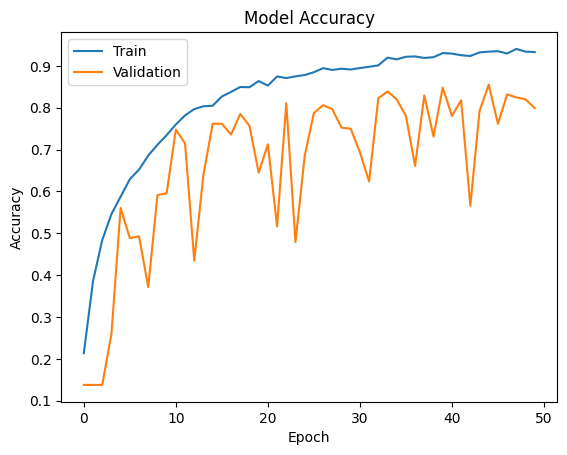

```python
plt.plot(history_1.history['accuracy'])
plt.plot(history_1.history['val_accuracy'])
plt.title('Model Accuracy')
plt.ylabel('Accuracy')
plt.xlabel('Epoch')
plt.legend(['Train', 'Validation'], loc='upper left')
plt.show()
```

**Key Observations**

- Model is overfitting while the performance on training data is smooth, the validation accuracy spiked a lot.
- Model performs poorly on validation dataset, though some amount of hyper parameter tuning was done with batch normalization, drop out and L2 regularization.
- Lets try with data augmentation

### Evaluating the model on test data

```python
accuracy = model.evaluate(X_test_normalized, y_test_encoded, verbose=2)
```

```
15/15 - 2s - 104ms/step - accuracy: 0.7537 - loss: 1.2366
```

```python
y_pred = model.predict(X_test_normalized)
```

```
15/15 ━━━━━━━━━━━━━━━━━━━━ 1s 42ms/step
```

### **Plotting the Confusion Matrix**

- The Confusion matrix is also defined as an inbuilt function in the TensorFlow module, so we can use that for evaluating the classification model.
- The Confusion matrix expects categorical data as input. However, y_test_encoded is an encoded value, whereas y_pred has probabilities. So,we must retrieve the categorical values from the encoded values.
- We will use the `argmax()` function to obtain the maximum value over each category on both y_test_encoded and y_pred and obtain their respective classes.

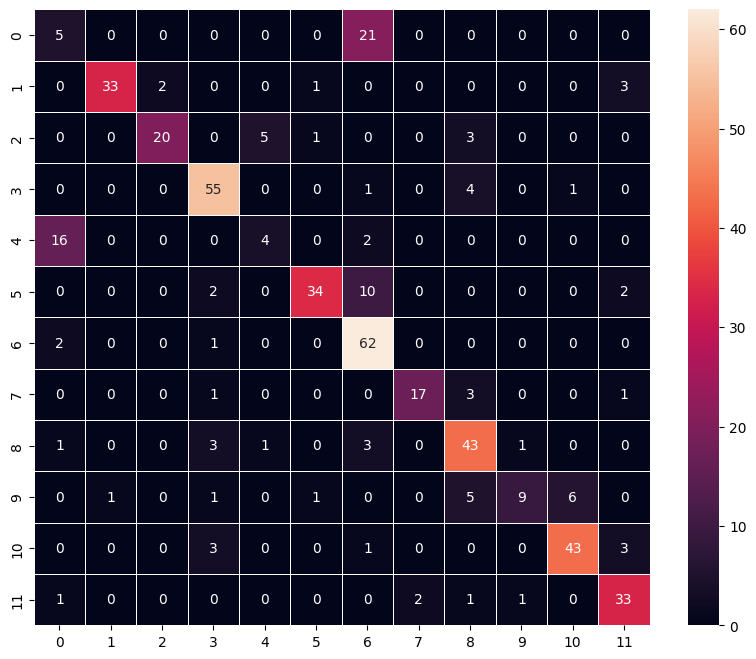

```python
# Obtaining the categorical values from y_test_encoded and y_pred
y_pred_arg=np.argmax(y_pred,axis=1)
y_test_arg=np.argmax(y_test_encoded,axis=1)

# Plotting the Confusion Matrix using confusion matrix() function which is also predefined tensorflow module
confusion_matrix = tf.math.confusion_matrix(y_test_arg,y_pred_arg)
f, ax = plt.subplots(figsize=(10, 8))
sns.heatmap(
    confusion_matrix,
    annot=True,
    linewidths=.4,
    fmt="d",
    square=True,
    ax=ax
)
plt.show()
```

# Model-2

## **Data Augmentation**

In most of the real-world case studies, it is challenging to acquire a large number of images and then train CNNs. To overcome this problem, one approach we might consider is **Data Augmentation**. CNNs have the property of **translational invariance**, which means they can recognise an object even if its appearance shifts translationally in some way.  
Taking this attribute into account, we can augment the images using the techniques listed below -  
**1. Horizontal Flip** (should be set to True/False)  
**2. Vertical Flip** (should be set to True/False)  
**3. Height Shift** (should be between 0 and 1)  
**4. Width Shift** (should be between 0 and 1)  
**5. Rotation** (should be between 0 and 180)  
**6. Shear** (should be between 0 and 1)  
**7. Zoom** (should be between 0 and 1) etc.

Remember, **data augmentation should not be used in the validation/test data set**.

```python
# Clearing backend
from tensorflow.keras import backend
backend.clear_session()

# Fixing the seed for random number generators
import random
np.random.seed(42)
random.seed(42)
tf.random.set_seed(42)
```

```python
# All images to be rescaled by 1/255.
train_datagen = ImageDataGenerator(rescale=1. / 255.0,
                              horizontal_flip = True,
                              vertical_flip = False,
                              height_shift_range= 0.1,
                              width_shift_range=0.1,
                              rotation_range=20,
                              shear_range = 0.1,
                              zoom_range=0.1)
test_datagen  = ImageDataGenerator(rescale = 1.0/255.)
```

```python
# Intializing a sequential model
model2 = Sequential()

# Adding first conv layer with 64 filters and kernel size 3x3 , padding 'same' provides the output size same as the input size
# Input_shape denotes input image dimension images
model2.add(Conv2D(64, (3, 3), activation='relu', padding="same", kernel_regularizer=regularizers.l2(0.001), input_shape=(64, 64, 3)))

# Adding max pooling to reduce the size of output of first conv layer
model2.add(MaxPooling2D((2, 2),  padding = 'same'))
model2.add(BatchNormalization())
model2.add(Conv2D(64, (3, 3), activation='relu', kernel_regularizer=regularizers.l2(0.001), padding="same"))
model2.add(MaxPooling2D((2, 2), padding = 'same'))
model2.add(BatchNormalization())
model2.add(Conv2D(32, (3, 3), activation='relu', kernel_regularizer=regularizers.l2(0.001), padding="same"))
model2.add(MaxPooling2D((2, 2), padding = 'same'))
model2.add(Conv2D(32, (3, 3), activation='relu', kernel_regularizer=regularizers.l2(0.001), padding="same"))
model2.add(MaxPooling2D((2, 2), padding = 'same'))
# flattening the output of the conv layer after max pooling to make it ready for creating dense connections
model2.add(Flatten())

# Adding a fully connected dense layer with 64 neurons
model2.add(Dense(64, activation='relu'))
model2.add(Dropout(0.25))
# Adding a fully connected dense layer with 32 neurons
model2.add(Dense(32, activation='relu'))
model2.add(Dropout(0.25))
# Adding a fully connected dense layer with 16 neurons
model2.add(Dense(32, activation='relu'))
# Adding the output layer with 10 neurons and activation functions as softmax since this is a multi-class classification problem
model2.add(Dense(12, activation='softmax'))

# Using SGD Optimizer
# opt = SGD(learning_rate=0.01, momentum=0.9)
#opt=Adam()
# Compile model
model2.compile(optimizer='adam', loss='categorical_crossentropy', metrics=['accuracy'])

# Generating the summary of the model
model2.summary()
```

```
Model: "sequential"
```

```
┏━━━━━━━━━━━━━━━━━━━━━━━━━━━━━━━━━━━━━━┳━━━━━━━━━━━━━━━━━━━━━━━━━━━━━┳━━━━━━━━━━━━━━━━━┓
┃ Layer (type)                         ┃ Output Shape                ┃         Param # ┃
┡━━━━━━━━━━━━━━━━━━━━━━━━━━━━━━━━━━━━━━╇━━━━━━━━━━━━━━━━━━━━━━━━━━━━━╇━━━━━━━━━━━━━━━━━┩
│ conv2d (Conv2D)                      │ (None, 64, 64, 64)          │           1,792 │
├──────────────────────────────────────┼─────────────────────────────┼─────────────────┤
│ max_pooling2d (MaxPooling2D)         │ (None, 32, 32, 64)          │               0 │
├──────────────────────────────────────┼─────────────────────────────┼─────────────────┤
│ batch_normalization                  │ (None, 32, 32, 64)          │             256 │
│ (BatchNormalization)                 │                             │                 │
├──────────────────────────────────────┼─────────────────────────────┼─────────────────┤
│ conv2d_1 (Conv2D)                    │ (None, 32, 32, 64)          │          36,928 │
├──────────────────────────────────────┼─────────────────────────────┼─────────────────┤
│ max_pooling2d_1 (MaxPooling2D)       │ (None, 16, 16, 64)          │               0 │
├──────────────────────────────────────┼─────────────────────────────┼─────────────────┤
│ batch_normalization_1                │ (None, 16, 16, 64)          │             256 │
│ (BatchNormalization)                 │                             │                 │
├──────────────────────────────────────┼─────────────────────────────┼─────────────────┤
│ conv2d_2 (Conv2D)                    │ (None, 16, 16, 32)          │          18,464 │
├──────────────────────────────────────┼─────────────────────────────┼─────────────────┤
│ max_pooling2d_2 (MaxPooling2D)       │ (None, 8, 8, 32)            │               0 │
├──────────────────────────────────────┼─────────────────────────────┼─────────────────┤
│ conv2d_3 (Conv2D)                    │ (None, 8, 8, 32)            │           9,248 │
├──────────────────────────────────────┼─────────────────────────────┼─────────────────┤
│ max_pooling2d_3 (MaxPooling2D)       │ (None, 4, 4, 32)            │               0 │
├──────────────────────────────────────┼─────────────────────────────┼─────────────────┤
│ flatten (Flatten)                    │ (None, 512)                 │               0 │
├──────────────────────────────────────┼─────────────────────────────┼─────────────────┤
│ dense (Dense)                        │ (None, 64)                  │          32,832 │
├──────────────────────────────────────┼─────────────────────────────┼─────────────────┤
│ dropout (Dropout)                    │ (None, 64)                  │               0 │
├──────────────────────────────────────┼─────────────────────────────┼─────────────────┤
│ dense_1 (Dense)                      │ (None, 32)                  │           2,080 │
├──────────────────────────────────────┼─────────────────────────────┼─────────────────┤
│ dropout_1 (Dropout)                  │ (None, 32)                  │               0 │
├──────────────────────────────────────┼─────────────────────────────┼─────────────────┤
│ dense_2 (Dense)                      │ (None, 32)                  │           1,056 │
├──────────────────────────────────────┼─────────────────────────────┼─────────────────┤
│ dense_3 (Dense)                      │ (None, 12)                  │             396 │
└──────────────────────────────────────┴─────────────────────────────┴─────────────────┘
```

```
 Total params: 103,308 (403.55 KB)
```

```
 Trainable params: 103,052 (402.55 KB)
```

```
 Non-trainable params: 256 (1.00 KB)
```

```python
# Epochs
epochs = 50
# Batch size
batch_size = 32

history = model2.fit(train_datagen.flow(X_train_normalized,y_train_encoded,
                                       batch_size=batch_size,
                                       seed=42,
                                       shuffle=False),
                    epochs=epochs,
                    steps_per_epoch=X_train_normalized.shape[0] // batch_size,
                    validation_data=(X_val_normalized,y_val_encoded),
                    verbose=1)
```

```
120/120 ━━━━━━━━━━━━━━━━━━━━ 19s 101ms/step - accuracy: 0.1585 - loss: 2.4651 - val_accuracy: 0.1285 - val_loss: 2.9745
120/120 ━━━━━━━━━━━━━━━━━━━━ 0s 625us/step - accuracy: 0.2188 - loss: 2.2105 - val_accuracy: 0.1285 - val_loss: 2.9333
120/120 ━━━━━━━━━━━━━━━━━━━━ 9s 43ms/step - accuracy: 0.3520 - loss: 1.8907 - val_accuracy: 0.1285 - val_loss: 12.6713
120/120 ━━━━━━━━━━━━━━━━━━━━ 0s 734us/step - accuracy: 0.5000 - loss: 1.6642 - val_accuracy: 0.1285 - val_loss: 13.1436
120/120 ━━━━━━━━━━━━━━━━━━━━ 11s 51ms/step - accuracy: 0.4485 - loss: 1.6489 - val_accuracy: 0.1285 - val_loss: 45.3680
120/120 ━━━━━━━━━━━━━━━━━━━━ 0s 714us/step - accuracy: 0.4688 - loss: 1.5589 - val_accuracy: 0.1285 - val_loss: 49.0804
120/120 ━━━━━━━━━━━━━━━━━━━━ 11s 58ms/step - accuracy: 0.4893 - loss: 1.4929 - val_accuracy: 0.1355 - val_loss: 81.5585
120/120 ━━━━━━━━━━━━━━━━━━━━ 0s 707us/step - accuracy: 0.5312 - loss: 1.5429 - val_accuracy: 0.1332 - val_loss: 88.1461
120/120 ━━━━━━━━━━━━━━━━━━━━ 8s 43ms/step - accuracy: 0.5290 - loss: 1.3984 - val_accuracy: 0.1379 - val_loss: 256.3364
120/120 ━━━━━━━━━━━━━━━━━━━━ 0s 600us/step - accuracy: 0.5000 - loss: 1.5521 - val_accuracy: 0.1425 - val_loss: 249.3090
120/120 ━━━━━━━━━━━━━━━━━━━━ 7s 58ms/step - accuracy: 0.5609 - loss: 1.3376 - val_accuracy: 0.1495 - val_loss: 348.8962
120/120 ━━━━━━━━━━━━━━━━━━━━ 0s 714us/step - accuracy: 0.3438 - loss: 1.7417 - val_accuracy: 0.1542 - val_loss: 306.1726
120/120 ━━━━━━━━━━━━━━━━━━━━ 8s 44ms/step - accuracy: 0.5845 - loss: 1.2554 - val_accuracy: 0.1706 - val_loss: 272.0751
120/120 ━━━━━━━━━━━━━━━━━━━━ 0s 821us/step - accuracy: 0.5312 - loss: 1.7816 - val_accuracy: 0.1776 - val_loss: 273.3746
120/120 ━━━━━━━━━━━━━━━━━━━━ 7s 56ms/step - accuracy: 0.5877 - loss: 1.2466 - val_accuracy: 0.2220 - val_loss: 215.2389
120/120 ━━━━━━━━━━━━━━━━━━━━ 0s 613us/step - accuracy: 0.6875 - loss: 1.0494 - val_accuracy: 0.2336 - val_loss: 204.7200
120/120 ━━━━━━━━━━━━━━━━━━━━ 9s 49ms/step - accuracy: 0.6094 - loss: 1.1680 - val_accuracy: 0.0631 - val_loss: 1137.6351
120/120 ━━━━━━━━━━━━━━━━━━━━ 0s 2ms/step - accuracy: 0.6562 - loss: 1.0442 - val_accuracy: 0.0584 - val_loss: 1215.8558
120/120 ━━━━━━━━━━━━━━━━━━━━ 9s 43ms/step - accuracy: 0.6339 - loss: 1.1171 - val_accuracy: 0.0607 - val_loss: 1393.9302
120/120 ━━━━━━━━━━━━━━━━━━━━ 0s 728us/step - accuracy: 0.6875 - loss: 1.0398 - val_accuracy: 0.0607 - val_loss: 1482.8926
120/120 ━━━━━━━━━━━━━━━━━━━━ 7s 58ms/step - accuracy: 0.6244 - loss: 1.1401 - val_accuracy: 0.0421 - val_loss: 3070.8479
120/120 ━━━━━━━━━━━━━━━━━━━━ 0s 623us/step - accuracy: 0.6562 - loss: 1.3059 - val_accuracy: 0.0467 - val_loss: 3070.5730
120/120 ━━━━━━━━━━━━━━━━━━━━ 5s 43ms/step - accuracy: 0.6648 - loss: 1.0378 - val_accuracy: 0.0467 - val_loss: 2748.3755
120/120 ━━━━━━━━━━━━━━━━━━━━ 0s 635us/step - accuracy: 0.6875 - loss: 1.0311 - val_accuracy: 0.0467 - val_loss: 2656.5176
120/120 ━━━━━━━━━━━━━━━━━━━━ 11s 46ms/step - accuracy: 0.6663 - loss: 1.0175 - val_accuracy: 0.1379 - val_loss: 3599.6904
120/120 ━━━━━━━━━━━━━━━━━━━━ 0s 749us/step - accuracy: 0.6875 - loss: 1.2460 - val_accuracy: 0.1379 - val_loss: 3651.1709
120/120 ━━━━━━━━━━━━━━━━━━━━ 11s 58ms/step - accuracy: 0.6575 - loss: 1.0443 - val_accuracy: 0.0467 - val_loss: 3961.8916
120/120 ━━━━━━━━━━━━━━━━━━━━ 0s 714us/step - accuracy: 0.6875 - loss: 0.5876 - val_accuracy: 0.0467 - val_loss: 3816.2490
120/120 ━━━━━━━━━━━━━━━━━━━━ 9s 45ms/step - accuracy: 0.6926 - loss: 0.9866 - val_accuracy: 0.0491 - val_loss: 3212.4363
120/120 ━━━━━━━━━━━━━━━━━━━━ 0s 2ms/step - accuracy: 0.8125 - loss: 0.7744 - val_accuracy: 0.0491 - val_loss: 3200.9951
120/120 ━━━━━━━━━━━━━━━━━━━━ 10s 42ms/step - accuracy: 0.6855 - loss: 0.9826 - val_accuracy: 0.1285 - val_loss: 1867.3127
120/120 ━━━━━━━━━━━━━━━━━━━━ 0s 730us/step - accuracy: 0.7812 - loss: 0.9168 - val_accuracy: 0.1238 - val_loss: 1828.6860
120/120 ━━━━━━━━━━━━━━━━━━━━ 9s 75ms/step - accuracy: 0.7063 - loss: 0.9118 - val_accuracy: 0.1379 - val_loss: 3283.6340
120/120 ━━━━━━━━━━━━━━━━━━━━ 0s 669us/step - accuracy: 0.8125 - loss: 0.7688 - val_accuracy: 0.1379 - val_loss: 3320.2681
120/120 ━━━━━━━━━━━━━━━━━━━━ 5s 43ms/step - accuracy: 0.6976 - loss: 0.9410 - val_accuracy: 0.1425 - val_loss: 3112.0042
120/120 ━━━━━━━━━━━━━━━━━━━━ 0s 718us/step - accuracy: 0.7500 - loss: 1.3579 - val_accuracy: 0.1379 - val_loss: 3290.0154
120/120 ━━━━━━━━━━━━━━━━━━━━ 6s 50ms/step - accuracy: 0.7079 - loss: 0.9310 - val_accuracy: 0.1285 - val_loss: 2371.5005
120/120 ━━━━━━━━━━━━━━━━━━━━ 0s 2ms/step - accuracy: 0.7188 - loss: 0.8349 - val_accuracy: 0.1379 - val_loss: 2458.7249
120/120 ━━━━━━━━━━━━━━━━━━━━ 9s 44ms/step - accuracy: 0.6994 - loss: 0.9206 - val_accuracy: 0.1379 - val_loss: 2723.5879
120/120 ━━━━━━━━━━━━━━━━━━━━ 0s 726us/step - accuracy: 0.7500 - loss: 0.8188 - val_accuracy: 0.1402 - val_loss: 2630.0979
120/120 ━━━━━━━━━━━━━━━━━━━━ 7s 59ms/step - accuracy: 0.7172 - loss: 0.8918 - val_accuracy: 0.1519 - val_loss: 1938.0022
120/120 ━━━━━━━━━━━━━━━━━━━━ 0s 735us/step - accuracy: 0.8125 - loss: 0.9882 - val_accuracy: 0.1472 - val_loss: 1946.6703
120/120 ━━━━━━━━━━━━━━━━━━━━ 5s 43ms/step - accuracy: 0.7402 - loss: 0.8400 - val_accuracy: 0.0467 - val_loss: 2642.4592
120/120 ━━━━━━━━━━━━━━━━━━━━ 0s 613us/step - accuracy: 0.7812 - loss: 0.8637 - val_accuracy: 0.0467 - val_loss: 2687.9951
120/120 ━━━━━━━━━━━━━━━━━━━━ 10s 44ms/step - accuracy: 0.7394 - loss: 0.8462 - val_accuracy: 0.1379 - val_loss: 2969.1558
120/120 ━━━━━━━━━━━━━━━━━━━━ 0s 732us/step - accuracy: 0.7188 - loss: 0.8884 - val_accuracy: 0.1379 - val_loss: 2998.0129
120/120 ━━━━━━━━━━━━━━━━━━━━ 6s 45ms/step - accuracy: 0.7283 - loss: 0.8264 - val_accuracy: 0.0981 - val_loss: 2453.8687
120/120 ━━━━━━━━━━━━━━━━━━━━ 0s 1ms/step - accuracy: 0.7500 - loss: 0.7630 - val_accuracy: 0.1308 - val_loss: 2399.7290
120/120 ━━━━━━━━━━━━━━━━━━━━ 7s 54ms/step - accuracy: 0.7561 - loss: 0.7828 - val_accuracy: 0.1449 - val_loss: 3210.9089
120/120 ━━━━━━━━━━━━━━━━━━━━ 0s 725us/step - accuracy: 0.6250 - loss: 0.9635 - val_accuracy: 0.1519 - val_loss: 3074.0786
```

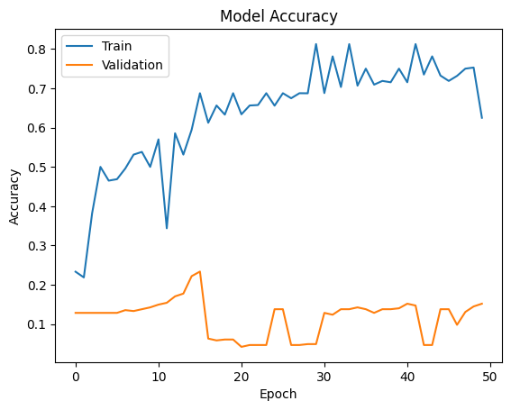

```python
plt.plot(history.history['accuracy'])
plt.plot(history.history['val_accuracy'])
plt.title('Model Accuracy')
plt.ylabel('Accuracy')
plt.xlabel('Epoch')
plt.legend(['Train', 'Validation'], loc='upper left')
plt.show()
```

```python
accuracy = model2.evaluate(X_test_normalized, y_test_encoded, verbose=2)
```

```
15/15 - 1s - 68ms/step - accuracy: 0.1558 - loss: 3153.2607
```

**Model is Overfit and poorly performing on training and validation data**

```python
y_pred = model2.predict(X_test_normalized)
```

```
15/15 ━━━━━━━━━━━━━━━━━━━━ 1s 28ms/step
```

```python
y_pred[0:10]
```

```
array([[0.000000e+00, 0.000000e+00, 0.000000e+00, 0.000000e+00,
        0.000000e+00, 0.000000e+00, 0.000000e+00, 1.000000e+00,
        0.000000e+00, 0.000000e+00, 0.000000e+00, 0.000000e+00],
       [0.000000e+00, 0.000000e+00, 0.000000e+00, 0.000000e+00,
        0.000000e+00, 0.000000e+00, 0.000000e+00, 1.000000e+00,
        0.000000e+00, 0.000000e+00, 0.000000e+00, 0.000000e+00],
       [0.000000e+00, 0.000000e+00, 0.000000e+00, 0.000000e+00,
        0.000000e+00, 0.000000e+00, 0.000000e+00, 1.000000e+00,
        0.000000e+00, 0.000000e+00, 0.000000e+00, 0.000000e+00],
       [0.000000e+00, 0.000000e+00, 0.000000e+00, 0.000000e+00,
        0.000000e+00, 0.000000e+00, 1.000000e+00, 0.000000e+00,
        0.000000e+00, 0.000000e+00, 0.000000e+00, 0.000000e+00],
       [0.000000e+00, 0.000000e+00, 0.000000e+00, 0.000000e+00,
        0.000000e+00, 0.000000e+00, 0.000000e+00, 1.000000e+00,
        0.000000e+00, 0.000000e+00, 0.000000e+00, 0.000000e+00],
       [0.000000e+00, 0.000000e+00, 0.000000e+00, 0.000000e+00,
        0.000000e+00, 0.000000e+00, 1.000000e+00, 0.000000e+00,
        0.000000e+00, 0.000000e+00, 0.000000e+00, 0.000000e+00],
       [0.000000e+00, 0.000000e+00, 0.000000e+00, 0.000000e+00,
        0.000000e+00, 0.000000e+00, 1.000000e+00, 0.000000e+00,
        0.000000e+00, 0.000000e+00, 0.000000e+00, 0.000000e+00],
       [0.000000e+00, 0.000000e+00, 0.000000e+00, 0.000000e+00,
        0.000000e+00, 0.000000e+00, 1.000000e+00, 0.000000e+00,
        0.000000e+00, 0.000000e+00, 0.000000e+00, 0.000000e+00],
       [0.000000e+00, 0.000000e+00, 0.000000e+00, 0.000000e+00,
        0.000000e+00, 0.000000e+00, 1.000000e+00, 3.599859e-31,
        0.000000e+00, 0.000000e+00, 0.000000e+00, 0.000000e+00],
       [0.000000e+00, 0.000000e+00, 0.000000e+00, 0.000000e+00,
        0.000000e+00, 0.000000e+00, 1.000000e+00, 0.000000e+00,
        0.000000e+00, 0.000000e+00, 0.000000e+00, 0.000000e+00]],
      dtype=float32)
```

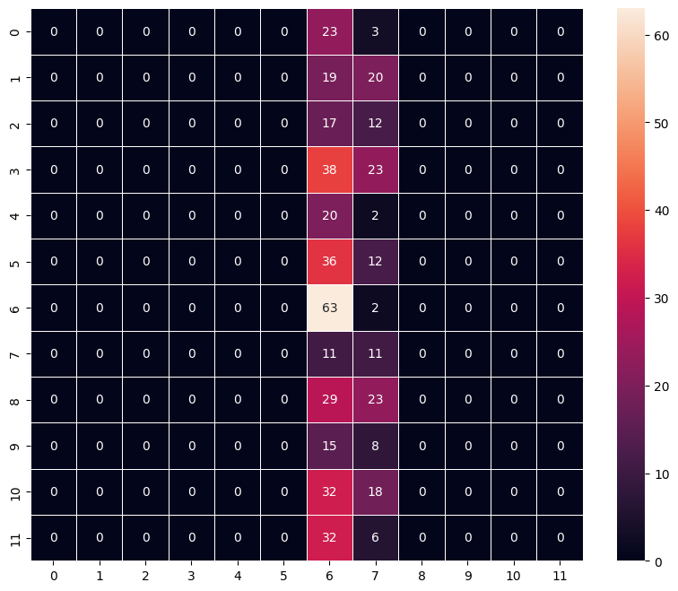

```python
# Obtaining the categorical values from y_test_encoded and y_pred
y_pred_arg=np.argmax(y_pred,axis=1)
y_test_arg=np.argmax(y_test_encoded,axis=1)

# Plotting the Confusion Matrix using confusion matrix() function which is also predefined tensorflow module
confusion_matrix = tf.math.confusion_matrix(y_test_arg,y_pred_arg)
f, ax = plt.subplots(figsize=(10, 8))
sns.heatmap(
    confusion_matrix,
    annot=True,
    linewidths=.4,
    fmt="d",
    square=True,
    ax=ax
)
plt.show()
```

## Model Performance Improvement

### **Data Augmentation**

Remember, **data augmentation should not be used in the validation/test data set**.

### Transfer Learning using VGG 16

- Let's try again, but this time, we will be using the idea of **Transfer Learning**. We will be loading a pre-built architecture - **VGG16**, which was trained on the ImageNet dataset and is the runner-up in the ImageNet competition in 2014.
- For training VGG16, we will directly use the convolutional and pooling layers and freeze their weights i.e. no training will be done on them. For classification, we will replace the existing fully-connected layers with FC layers created specifically for our problem.

```python
# Clearing backend
from tensorflow.keras import backend
backend.clear_session()

# Fixing the seed for random number generators
import random
np.random.seed(42)
random.seed(42)
tf.random.set_seed(42)
```

```python
from tensorflow.keras.models import Model
from keras.applications.vgg16 import VGG16

vgg_model = VGG16(weights='imagenet', include_top = False, input_shape = (224, 224, 3))
vgg_model.summary()
```

```
Downloading data from https://storage.googleapis.com/tensorflow/keras-applications/vgg16/vgg16_weights_tf_dim_ordering_tf_kernels_notop.h5
58889256/58889256 ━━━━━━━━━━━━━━━━━━━━ 0s 0us/step
```

```
Model: "vgg16"
```

```
┏━━━━━━━━━━━━━━━━━━━━━━━━━━━━━━━━━━━━━━┳━━━━━━━━━━━━━━━━━━━━━━━━━━━━━┳━━━━━━━━━━━━━━━━━┓
┃ Layer (type)                         ┃ Output Shape                ┃         Param # ┃
┡━━━━━━━━━━━━━━━━━━━━━━━━━━━━━━━━━━━━━━╇━━━━━━━━━━━━━━━━━━━━━━━━━━━━━╇━━━━━━━━━━━━━━━━━┩
│ input_layer (InputLayer)             │ (None, 224, 224, 3)         │               0 │
├──────────────────────────────────────┼─────────────────────────────┼─────────────────┤
│ block1_conv1 (Conv2D)                │ (None, 224, 224, 64)        │           1,792 │
├──────────────────────────────────────┼─────────────────────────────┼─────────────────┤
│ block1_conv2 (Conv2D)                │ (None, 224, 224, 64)        │          36,928 │
├──────────────────────────────────────┼─────────────────────────────┼─────────────────┤
│ block1_pool (MaxPooling2D)           │ (None, 112, 112, 64)        │               0 │
├──────────────────────────────────────┼─────────────────────────────┼─────────────────┤
│ block2_conv1 (Conv2D)                │ (None, 112, 112, 128)       │          73,856 │
├──────────────────────────────────────┼─────────────────────────────┼─────────────────┤
│ block2_conv2 (Conv2D)                │ (None, 112, 112, 128)       │         147,584 │
├──────────────────────────────────────┼─────────────────────────────┼─────────────────┤
│ block2_pool (MaxPooling2D)           │ (None, 56, 56, 128)         │               0 │
├──────────────────────────────────────┼─────────────────────────────┼─────────────────┤
│ block3_conv1 (Conv2D)                │ (None, 56, 56, 256)         │         295,168 │
├──────────────────────────────────────┼─────────────────────────────┼─────────────────┤
│ block3_conv2 (Conv2D)                │ (None, 56, 56, 256)         │         590,080 │
├──────────────────────────────────────┼─────────────────────────────┼─────────────────┤
│ block3_conv3 (Conv2D)                │ (None, 56, 56, 256)         │         590,080 │
├──────────────────────────────────────┼─────────────────────────────┼─────────────────┤
│ block3_pool (MaxPooling2D)           │ (None, 28, 28, 256)         │               0 │
├──────────────────────────────────────┼─────────────────────────────┼─────────────────┤
│ block4_conv1 (Conv2D)                │ (None, 28, 28, 512)         │       1,180,160 │
├──────────────────────────────────────┼─────────────────────────────┼─────────────────┤
│ block4_conv2 (Conv2D)                │ (None, 28, 28, 512)         │       2,359,808 │
├──────────────────────────────────────┼─────────────────────────────┼─────────────────┤
│ block4_conv3 (Conv2D)                │ (None, 28, 28, 512)         │       2,359,808 │
├──────────────────────────────────────┼─────────────────────────────┼─────────────────┤
│ block4_pool (MaxPooling2D)           │ (None, 14, 14, 512)         │               0 │
├──────────────────────────────────────┼─────────────────────────────┼─────────────────┤
│ block5_conv1 (Conv2D)                │ (None, 14, 14, 512)         │       2,359,808 │
├──────────────────────────────────────┼─────────────────────────────┼─────────────────┤
│ block5_conv2 (Conv2D)                │ (None, 14, 14, 512)         │       2,359,808 │
├──────────────────────────────────────┼─────────────────────────────┼─────────────────┤
│ block5_conv3 (Conv2D)                │ (None, 14, 14, 512)         │       2,359,808 │
├──────────────────────────────────────┼─────────────────────────────┼─────────────────┤
│ block5_pool (MaxPooling2D)           │ (None, 7, 7, 512)           │               0 │
└──────────────────────────────────────┴─────────────────────────────┴─────────────────┘
```

```
 Total params: 14,714,688 (56.13 MB)
```

```
 Trainable params: 14,714,688 (56.13 MB)
```

```
 Non-trainable params: 0 (0.00 B)
```

```python
# Making all the layers of the VGG model non-trainable. i.e. freezing them
for layer in vgg_model.layers:
    layer.trainable = False
```

```python
for layer in vgg_model.layers:
    print(layer.name, layer.trainable)
```

```
input_layer False
block1_conv1 False
block1_conv2 False
block1_pool False
block2_conv1 False
block2_conv2 False
block2_pool False
block3_conv1 False
block3_conv2 False
block3_conv3 False
block3_pool False
block4_conv1 False
block4_conv2 False
block4_conv3 False
block4_pool False
block5_conv1 False
block5_conv2 False
block5_conv3 False
block5_pool False
```

```python
vg_model = Sequential()
# Adding the convolutional part of the VGG16 model from above
vg_model.add(vgg_model)
vg_model.add(Flatten())
# Adding a dense output layer
vg_model.add(Dense(64, activation='relu'))
vg_model.add(Dropout(0.2))
vg_model.add(Dense(32, activation='relu'))
vg_model.add(Dropout(0.2))
vg_model.add(Dense(12, activation='softmax'))
opt=Adam()
# Compile model
vg_model.compile(optimizer=opt, loss='categorical_crossentropy', metrics=['accuracy'])
```

```python
# All images to be rescaled by 1/255.
train_datagen = ImageDataGenerator(rescale=1. / 255.0,
                              horizontal_flip = True,
                              vertical_flip = False,
                              height_shift_range= 0.1,
                              width_shift_range=0.1,
                              rotation_range=20,
                              shear_range = 0.1,
                              zoom_range=0.1)
test_datagen  = ImageDataGenerator(rescale = 1.0/255.)
```

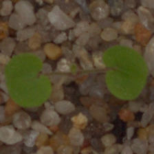

```python
images_increased = []
for i in range(len(images)):
  images_increased.append(cv2.resize(images[i], (224, 224)))
cv2_imshow(images_increased[0])
```

```python
X_temp, X_test, y_temp, y_test = train_test_split(np.array(images_increased),labels , test_size=0.1, random_state=42,stratify=labels)
X_train, X_val, y_train, y_val = train_test_split(X_temp,y_temp , test_size=0.1, random_state=42,stratify=y_temp)
```

```python
# Normalizing the image pixels
X_train_normalized = X_train.astype('float32')/255.0
X_val_normalized = X_val.astype('float32')/255.0
X_test_normalized = X_test.astype('float32')/255.0
```

```python
from sklearn.preprocessing import LabelBinarizer
enc = LabelBinarizer()
y_train_encoded = enc.fit_transform(y_train)
y_val_encoded=enc.transform(y_val)
y_test_encoded=enc.transform(y_test)
```

```python
# Epochs
epochs = 50
# Batch size
batch_size = 32

history = vg_model.fit(train_datagen.flow(X_train_normalized,y_train_encoded,
                                       batch_size=batch_size,
                                       seed=42,
                                       shuffle=False),
                    epochs=epochs,
                    steps_per_epoch = batch_size,
                    validation_data=(X_val_normalized,y_val_encoded),
                    verbose=1)
```

```
32/32 ━━━━━━━━━━━━━━━━━━━━ 42s 743ms/step - accuracy: 0.1087 - loss: 2.7658 - val_accuracy: 0.1168 - val_loss: 2.4842
32/32 ━━━━━━━━━━━━━━━━━━━━ 14s 450ms/step - accuracy: 0.1193 - loss: 2.4767 - val_accuracy: 0.1145 - val_loss: 2.4770
32/32 ━━━━━━━━━━━━━━━━━━━━ 13s 413ms/step - accuracy: 0.1243 - loss: 2.4665 - val_accuracy: 0.1098 - val_loss: 2.4691
32/32 ━━━━━━━━━━━━━━━━━━━━ 15s 468ms/step - accuracy: 0.1407 - loss: 2.4549 - val_accuracy: 0.1005 - val_loss: 2.4628
32/32 ━━━━━━━━━━━━━━━━━━━━ 79s 517ms/step - accuracy: 0.1617 - loss: 2.4505 - val_accuracy: 0.0911 - val_loss: 2.4555
32/32 ━━━━━━━━━━━━━━━━━━━━ 13s 427ms/step - accuracy: 0.1031 - loss: 2.4469 - val_accuracy: 0.0935 - val_loss: 2.4501
32/32 ━━━━━━━━━━━━━━━━━━━━ 15s 467ms/step - accuracy: 0.1208 - loss: 2.4442 - val_accuracy: 0.0935 - val_loss: 2.4455
32/32 ━━━━━━━━━━━━━━━━━━━━ 14s 444ms/step - accuracy: 0.1400 - loss: 2.4361 - val_accuracy: 0.0958 - val_loss: 2.4414
32/32 ━━━━━━━━━━━━━━━━━━━━ 44s 632ms/step - accuracy: 0.1277 - loss: 2.4280 - val_accuracy: 0.1051 - val_loss: 2.4370
32/32 ━━━━━━━━━━━━━━━━━━━━ 18s 590ms/step - accuracy: 0.1085 - loss: 2.4478 - val_accuracy: 0.1028 - val_loss: 2.4345
32/32 ━━━━━━━━━━━━━━━━━━━━ 18s 573ms/step - accuracy: 0.1365 - loss: 2.4172 - val_accuracy: 0.1121 - val_loss: 2.4321
32/32 ━━━━━━━━━━━━━━━━━━━━ 12s 372ms/step - accuracy: 0.1293 - loss: 2.4273 - val_accuracy: 0.1168 - val_loss: 2.4306
32/32 ━━━━━━━━━━━━━━━━━━━━ 21s 595ms/step - accuracy: 0.1409 - loss: 2.4401 - val_accuracy: 0.1192 - val_loss: 2.4292
32/32 ━━━━━━━━━━━━━━━━━━━━ 16s 520ms/step - accuracy: 0.1541 - loss: 2.4249 - val_accuracy: 0.1355 - val_loss: 2.4281
32/32 ━━━━━━━━━━━━━━━━━━━━ 15s 483ms/step - accuracy: 0.1314 - loss: 2.4115 - val_accuracy: 0.1379 - val_loss: 2.4271
32/32 ━━━━━━━━━━━━━━━━━━━━ 10s 326ms/step - accuracy: 0.1232 - loss: 2.4147 - val_accuracy: 0.1121 - val_loss: 2.4264
32/32 ━━━━━━━━━━━━━━━━━━━━ 38s 472ms/step - accuracy: 0.1395 - loss: 2.4200 - val_accuracy: 0.1285 - val_loss: 2.4260
32/32 ━━━━━━━━━━━━━━━━━━━━ 14s 444ms/step - accuracy: 0.1562 - loss: 2.4168 - val_accuracy: 0.1285 - val_loss: 2.4258
32/32 ━━━━━━━━━━━━━━━━━━━━ 13s 424ms/step - accuracy: 0.1048 - loss: 2.4308 - val_accuracy: 0.1168 - val_loss: 2.4257
32/32 ━━━━━━━━━━━━━━━━━━━━ 8s 244ms/step - accuracy: 0.1273 - loss: 2.4331 - val_accuracy: 0.1192 - val_loss: 2.4253
32/32 ━━━━━━━━━━━━━━━━━━━━ 45s 453ms/step - accuracy: 0.1305 - loss: 2.4501 - val_accuracy: 0.1192 - val_loss: 2.4249
32/32 ━━━━━━━━━━━━━━━━━━━━ 15s 483ms/step - accuracy: 0.1437 - loss: 2.4218 - val_accuracy: 0.1262 - val_loss: 2.4247
32/32 ━━━━━━━━━━━━━━━━━━━━ 15s 473ms/step - accuracy: 0.1244 - loss: 2.4211 - val_accuracy: 0.1192 - val_loss: 2.4247
32/32 ━━━━━━━━━━━━━━━━━━━━ 8s 260ms/step - accuracy: 0.1183 - loss: 2.4352 - val_accuracy: 0.1238 - val_loss: 2.4247
32/32 ━━━━━━━━━━━━━━━━━━━━ 46s 475ms/step - accuracy: 0.1413 - loss: 2.4153 - val_accuracy: 0.1238 - val_loss: 2.4248
32/32 ━━━━━━━━━━━━━━━━━━━━ 15s 465ms/step - accuracy: 0.1389 - loss: 2.4077 - val_accuracy: 0.1238 - val_loss: 2.4246
32/32 ━━━━━━━━━━━━━━━━━━━━ 14s 448ms/step - accuracy: 0.1281 - loss: 2.4142 - val_accuracy: 0.1262 - val_loss: 2.4244
32/32 ━━━━━━━━━━━━━━━━━━━━ 9s 292ms/step - accuracy: 0.1401 - loss: 2.4251 - val_accuracy: 0.1238 - val_loss: 2.4244
32/32 ━━━━━━━━━━━━━━━━━━━━ 45s 541ms/step - accuracy: 0.1040 - loss: 2.4470 - val_accuracy: 0.1238 - val_loss: 2.4246
32/32 ━━━━━━━━━━━━━━━━━━━━ 15s 467ms/step - accuracy: 0.1498 - loss: 2.3956 - val_accuracy: 0.1238 - val_loss: 2.4244
32/32 ━━━━━━━━━━━━━━━━━━━━ 14s 435ms/step - accuracy: 0.1346 - loss: 2.4108 - val_accuracy: 0.1192 - val_loss: 2.4246
32/32 ━━━━━━━━━━━━━━━━━━━━ 8s 251ms/step - accuracy: 0.1491 - loss: 2.4102 - val_accuracy: 0.1262 - val_loss: 2.4242
32/32 ━━━━━━━━━━━━━━━━━━━━ 25s 653ms/step - accuracy: 0.1783 - loss: 2.3932 - val_accuracy: 0.1238 - val_loss: 2.4239
32/32 ━━━━━━━━━━━━━━━━━━━━ 24s 773ms/step - accuracy: 0.1334 - loss: 2.4122 - val_accuracy: 0.1285 - val_loss: 2.4236
32/32 ━━━━━━━━━━━━━━━━━━━━ 13s 404ms/step - accuracy: 0.1002 - loss: 2.4377 - val_accuracy: 0.1262 - val_loss: 2.4237
32/32 ━━━━━━━━━━━━━━━━━━━━ 9s 271ms/step - accuracy: 0.1558 - loss: 2.4096 - val_accuracy: 0.1238 - val_loss: 2.4238
32/32 ━━━━━━━━━━━━━━━━━━━━ 29s 485ms/step - accuracy: 0.1266 - loss: 2.4108 - val_accuracy: 0.1285 - val_loss: 2.4238
32/32 ━━━━━━━━━━━━━━━━━━━━ 14s 433ms/step - accuracy: 0.1574 - loss: 2.4094 - val_accuracy: 0.1285 - val_loss: 2.4237
32/32 ━━━━━━━━━━━━━━━━━━━━ 13s 419ms/step - accuracy: 0.1455 - loss: 2.4138 - val_accuracy: 0.1285 - val_loss: 2.4238
32/32 ━━━━━━━━━━━━━━━━━━━━ 10s 310ms/step - accuracy: 0.1337 - loss: 2.4102 - val_accuracy: 0.1262 - val_loss: 2.4240
32/32 ━━━━━━━━━━━━━━━━━━━━ 17s 455ms/step - accuracy: 0.1273 - loss: 2.4217 - val_accuracy: 0.1238 - val_loss: 2.4243
32/32 ━━━━━━━━━━━━━━━━━━━━ 15s 468ms/step - accuracy: 0.1596 - loss: 2.4192 - val_accuracy: 0.1262 - val_loss: 2.4243
32/32 ━━━━━━━━━━━━━━━━━━━━ 14s 454ms/step - accuracy: 0.1288 - loss: 2.4184 - val_accuracy: 0.1262 - val_loss: 2.4239
32/32 ━━━━━━━━━━━━━━━━━━━━ 10s 314ms/step - accuracy: 0.1331 - loss: 2.4362 - val_accuracy: 0.1262 - val_loss: 2.4238
32/32 ━━━━━━━━━━━━━━━━━━━━ 17s 483ms/step - accuracy: 0.1306 - loss: 2.4211 - val_accuracy: 0.1238 - val_loss: 2.4238
32/32 ━━━━━━━━━━━━━━━━━━━━ 15s 487ms/step - accuracy: 0.1335 - loss: 2.4213 - val_accuracy: 0.1238 - val_loss: 2.4237
32/32 ━━━━━━━━━━━━━━━━━━━━ 13s 426ms/step - accuracy: 0.1190 - loss: 2.4032 - val_accuracy: 0.1262 - val_loss: 2.4238
32/32 ━━━━━━━━━━━━━━━━━━━━ 9s 280ms/step - accuracy: 0.1617 - loss: 2.3996 - val_accuracy: 0.1285 - val_loss: 2.4237
32/32 ━━━━━━━━━━━━━━━━━━━━ 16s 442ms/step - accuracy: 0.1248 - loss: 2.4172 - val_accuracy: 0.1262 - val_loss: 2.4236
32/32 ━━━━━━━━━━━━━━━━━━━━ 14s 435ms/step - accuracy: 0.1206 - loss: 2.4219 - val_accuracy: 0.1285 - val_loss: 2.4238
```

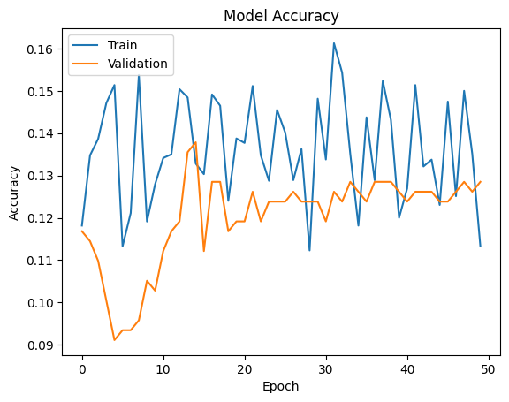

```python
plt.plot(history.history['accuracy'])
plt.plot(history.history['val_accuracy'])
plt.title('Model Accuracy')
plt.ylabel('Accuracy')
plt.xlabel('Epoch')
plt.legend(['Train', 'Validation'], loc='upper left')
plt.show()
```

```python
accuracy = vg_model.evaluate(X_test_normalized, y_test_encoded, verbose=2)
```

```
15/15 - 16s - 1s/step - accuracy: 0.1200 - loss: 2.4171
```

```python
y_pred = vg_model.predict(X_test_normalized)
```

```
15/15 ━━━━━━━━━━━━━━━━━━━━ 3s 150ms/step
```

```python
y_pred[0:10]
```

```
array([[0.05747109, 0.0784877 , 0.06195299, 0.12837781, 0.04981848,
        0.10020272, 0.13186722, 0.04830091, 0.10929447, 0.04942508,
        0.10452262, 0.08027896],
       [0.0567502 , 0.07377534, 0.06234216, 0.12610659, 0.05279686,
        0.10010432, 0.127141  , 0.05027292, 0.11473532, 0.04800028,
        0.1055785 , 0.0823965 ],
       [0.05512184, 0.07418719, 0.0616895 , 0.12541024, 0.0533038 ,
        0.10021248, 0.12818971, 0.0501604 , 0.118337  , 0.0473884 ,
        0.10534991, 0.08064958],
       [0.05633169, 0.0758241 , 0.06142087, 0.12823804, 0.05085509,
        0.10110252, 0.13072006, 0.04728355, 0.1148864 , 0.04757723,
        0.1070985 , 0.07866187],
       [0.05470973, 0.07361698, 0.05948818, 0.13042033, 0.05042989,
        0.10135188, 0.13405855, 0.04577731, 0.11814562, 0.04599724,
        0.10888741, 0.0771169 ],
       [0.05697817, 0.07948343, 0.06383986, 0.12831998, 0.05095473,
        0.09924415, 0.12788673, 0.05011901, 0.10753687, 0.05105724,
        0.10173128, 0.08284863],
       [0.05537722, 0.07318798, 0.0625303 , 0.13315223, 0.05028715,
        0.09533212, 0.13871948, 0.04763419, 0.11202579, 0.04824305,
        0.1056497 , 0.07786077],
       [0.05683098, 0.07423408, 0.06140309, 0.12742624, 0.05093643,
        0.1018801 , 0.12994209, 0.04845216, 0.11483392, 0.0475993 ,
        0.10804237, 0.07841922],
       [0.05639289, 0.07602844, 0.06165535, 0.12624483, 0.05202684,
        0.100888  , 0.12952979, 0.04880447, 0.11421397, 0.04840595,
        0.10553215, 0.08027736],
       [0.05615386, 0.07805108, 0.06227495, 0.1327721 , 0.04983811,
        0.09956294, 0.12836307, 0.04908284, 0.10977255, 0.04968891,
        0.10148124, 0.08295833]], dtype=float32)
```

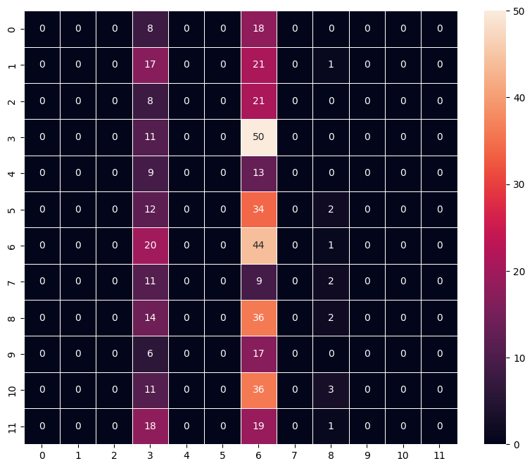

```python
# Obtaining the categorical values from y_test_encoded and y_pred
y_pred_arg=np.argmax(y_pred,axis=1)
y_test_arg=np.argmax(y_test_encoded,axis=1)

# Plotting the Confusion Matrix using confusion matrix() function which is also predefined tensorflow module
confusion_matrix = tf.math.confusion_matrix(y_test_arg,y_pred_arg)
f, ax = plt.subplots(figsize=(10, 8))
sns.heatmap(
    confusion_matrix,
    annot=True,
    linewidths=.4,
    fmt="d",
    square=True,
    ax=ax
)
plt.show()
```

## Actionable Insights and Business Recommendations

- Other CNN models like Imagenet or Resnet for our image processing problems.